# Analysis Of Complex Network_HW2

**Analysis Of Complex Network Course *Homework1* Yashar Movahedi *Student Id: 0232113102* Group:6**

**Facebook Dataset**:

```python
Part(a):Degree Distribution of the Network
```

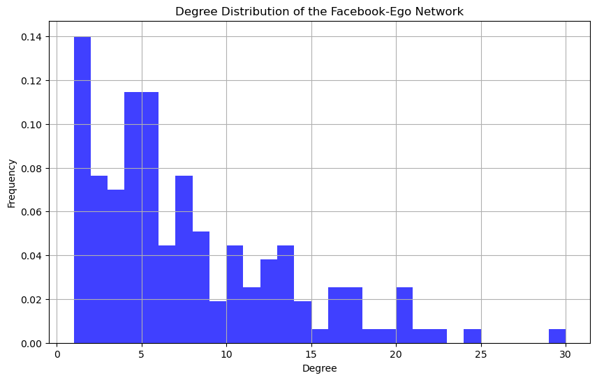

```python
import networkx as nx
import matplotlib.pyplot as plt


edges_file_path = 'C:/Users/Vampire/Desktop/complex/facebook/1684(1).edges'

# I Initialize an undirected graph for Facebook-Ego network
G = nx.Graph()

# Then I Read edges from the file and add them to the graph
with open(edges_file_path, 'r') as f:
    for line in f:
        node1, node2 = map(int, line.strip().split())
        G.add_edge(node1, node2)

# Plotting degree distribution
degrees = [G.degree(n) for n in G.nodes()]
plt.figure(figsize=(10, 6))
plt.hist(degrees, bins=range(1, max(degrees)+1), density=True, alpha=0.75, color='blue')
plt.title("Degree Distribution of the Facebook-Ego Network")
plt.xlabel("Degree")
plt.ylabel("Frequency")
plt.grid(True)
plt.show()
```

```python
Part(b):Comparison with Random Network
```

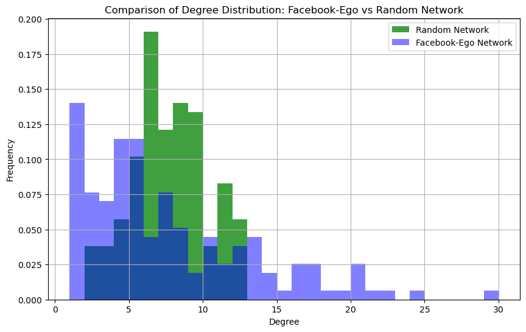

```python
# Get the number of nodes and edges in the original network
num_nodes = G.number_of_nodes()
num_edges = G.number_of_edges()

# Generate a random graph with the same number of nodes and edges
random_graph = nx.gnm_random_graph(num_nodes, num_edges)

# Degree distribution of the random graph
random_degrees = [random_graph.degree(n) for n in random_graph.nodes()]

# Plotting the degree distribution of the random network
plt.figure(figsize=(10, 6))
plt.hist(random_degrees, bins=range(1, max(random_degrees)+1), density=True, alpha=0.75, color='green', label='Random Network')
plt.hist(degrees, bins=range(1, max(degrees)+1), density=True, alpha=0.5, color='blue', label='Facebook-Ego Network')
plt.title("Comparison of Degree Distribution: Facebook-Ego vs Random Network")
plt.xlabel("Degree")
plt.ylabel("Frequency")
plt.legend()
plt.grid(True)
plt.show()
```

**Main difference between the Facebook network and a random network**: As we can observe the plot,in Facebook-Ego network The distribution is more skewed, with a few nodes having significantly higher degrees. On the other hand,in Random network The degree distribution is more concentrated around a central value, which is expected for random graphs. As a whole,The Facebook network has a power-law distribution, meaning a few nodes have many connections, while most have only a few. This is typical of scale-free networks, where connections grow through preferential attachment some nodes attract more connections over time. In contrast, a random network shows a more uniform or normal distribution, where most nodes have a similar number of connections, since edges are formed randomly without preference. In my idea the reason for this difference is that, in real-world networks like Facebook, some people (consider as nodes) naturally attract more connections over time, a process known as preferential attachment.

```python
Part(c):Average Path Length of the Network
```

```python
# Calculate the average path length for the largest connected component of the graph
if nx.is_connected(G):
    avg_path_length = nx.average_shortest_path_length(G)
else:
    # Get the largest connected component subgraph
    largest_cc = max(nx.connected_components(G), key=len)
    G_largest_cc = G.subgraph(largest_cc)
    avg_path_length = nx.average_shortest_path_length(G_largest_cc)

print(f"Average Path Length: {avg_path_length}")
```

```
Average Path Length: 4.097008666480291
```

```python
Part(d):Clustering Coefficients of 5 Randomly Chosen Nodes
```

```python
import random

# Randomly select 5 nodes from the graph
random_nodes = random.sample(G.nodes(), 5)

# Calculate the clustering coefficients for the selected nodes
clustering_coeffs = {node: nx.clustering(G, node) for node in random_nodes}
print("Clustering Coefficients for 5 Random Nodes:")
for node, coeff in clustering_coeffs.items():
    print(f"Node {node}: {coeff}")
```

```
Clustering Coefficients for 5 Random Nodes:
Node 2786: 0.3804347826086957
Node 2794: 0.6666666666666666
Node 2724: 0.18181818181818182
Node 2736: 0
Node 2674: 0.4722222222222222
```

```python
Part(e):Average Clustering Coefficient
```

```python
# Calculate the average clustering coefficient for the entire network
avg_clustering_coeff = nx.average_clustering(G)
print(f"Average Clustering Coefficient: {avg_clustering_coeff}")
```

```
Average Clustering Coefficient: 0.39469415134853486
```

```python
Part(f): Nodes in the Largest Connected Component
```

```python
# Get the largest connected component in the graph
largest_cc = max(nx.connected_components(G), key=len)
print("Nodes in the Largest Connected Component:")
print(largest_cc)
```

[output not shown]

**Twitter Dataset**:

```python
Part(a):Degree Distribution
```

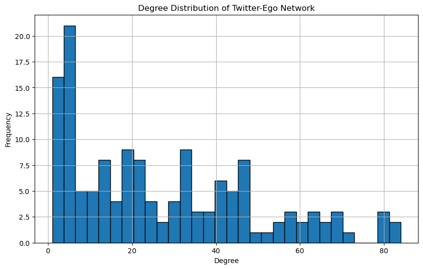

```python
import networkx as nx
import matplotlib.pyplot as plt

# Load the Twitter network
edges_file_path = 'C:/Users/Vampire/Desktop/complex/twitter/2029971.edges'
G_twitter_ego = nx.Graph()

with open(edges_file_path, 'r') as f:
    for line in f:
        node1, node2 = map(int, line.strip().split())
        G_twitter_ego.add_edge(node1, node2)

# (a) Degree Distribution
degree_sequence = [degree for node, degree in G_twitter_ego.degree()]
plt.figure(figsize=(10, 6))
plt.hist(degree_sequence, bins=30, edgecolor='black')
plt.title("Degree Distribution of Twitter-Ego Network")
plt.xlabel("Degree")
plt.ylabel("Frequency")
plt.grid(True)
plt.savefig('degree_distribution_twitter_ego.png')
plt.show()
```

```python
Part(b):Compare with a Random Network
```

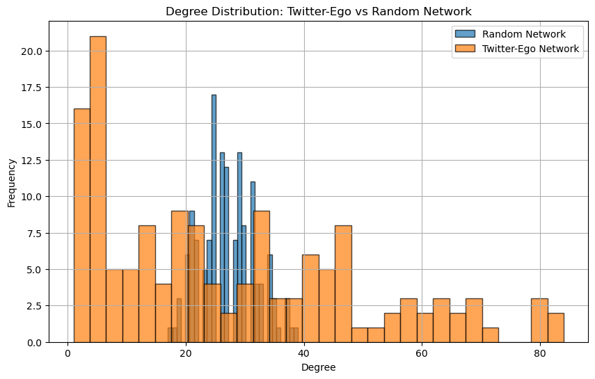

```python
import networkx as nx
import matplotlib.pyplot as plt


edges_file_path = 'C:/Users/Vampire/Desktop/complex/twitter/2029971.edges'
G_twitter_ego = nx.Graph()

with open(edges_file_path, 'r') as f:
    for line in f:
        node1, node2 = map(int, line.strip().split())
        G_twitter_ego.add_edge(node1, node2)

# Number of nodes and edges in the Twitter network
num_nodes = G_twitter_ego.number_of_nodes()
num_edges = G_twitter_ego.number_of_edges()

# Generate a random graph with the same number of nodes and edges
G_random = nx.gnm_random_graph(num_nodes, num_edges)

# Degree distribution of the random network
degree_sequence_random = [degree for node, degree in G_random.degree()]
plt.figure(figsize=(10, 6))
plt.hist(degree_sequence_random, bins=30, edgecolor='black', alpha=0.7, label='Random Network')
plt.hist(degree_sequence, bins=30, edgecolor='black', alpha=0.7, label='Twitter-Ego Network')
plt.title("Degree Distribution: Twitter-Ego vs Random Network")
plt.xlabel("Degree")
plt.ylabel("Frequency")
plt.legend()
plt.grid(True)
plt.savefig('degree_comparison_twitter_random.png')
plt.show()
```

```python
Part(c):Average Path Length
```

```python
import networkx as nx

edges_file_path = 'C:/Users/Vampire/Desktop/complex/twitter/2029971.edges'
G_twitter_ego = nx.Graph()

with open(edges_file_path, 'r') as f:
    for line in f:
        node1, node2 = map(int, line.strip().split())
        G_twitter_ego.add_edge(node1, node2)

# Find the largest connected component
largest_component = max(nx.connected_components(G_twitter_ego), key=len)
G_largest = G_twitter_ego.subgraph(largest_component).copy()

# Calculate the average path length of the largest component
if nx.is_connected(G_largest):
    avg_path_length = nx.average_shortest_path_length(G_largest)
    print(f"Average Path Length of the Largest Component: {avg_path_length}")
else:
    print("The largest component is not connected.")
```

```
Average Path Length of the Largest Component: 2.285432876982173
```

```python
Part(d):Clustering Coefficients of 5 Randomly Chosen Nodes
```

```python
import networkx as nx
import random

edges_file_path = 'C:/Users/Vampire/Desktop/complex/twitter/2029971.edges'
G_twitter_ego = nx.Graph()

with open(edges_file_path, 'r') as f:
    for line in f:
        node1, node2 = map(int, line.strip().split())
        G_twitter_ego.add_edge(node1, node2)

# Randomly choose 5 nodes from the network
random_nodes = random.sample(G_twitter_ego.nodes(), 5)

# Calculate the clustering coefficient for each node
clustering_coeffs = {}
for node in random_nodes:
    clustering_coeffs[node] = nx.clustering(G_twitter_ego, node)

print("Clustering Coefficients of 5 Randomly Chosen Nodes:")
for node, coeff in clustering_coeffs.items():
    print(f"Node {node}: Clustering Coefficient = {coeff}")
```

```
Clustering Coefficients of 5 Randomly Chosen Nodes:
Node 1809871: Clustering Coefficient = 0.3888888888888889
Node 17930661: Clustering Coefficient = 0.5002261420171868
Node 19814678: Clustering Coefficient = 0.6975806451612904
Node 16436311: Clustering Coefficient = 0.5333333333333333
Node 18485009: Clustering Coefficient = 0.6875
```

```python
Part(e):Average Clustering Coefficient
```

```python
import networkx as nx

edges_file_path = 'C:/Users/Vampire/Desktop/complex/twitter/2029971.edges'
G_twitter_ego = nx.Graph()

with open(edges_file_path, 'r') as f:
    for line in f:
        node1, node2 = map(int, line.strip().split())
        G_twitter_ego.add_edge(node1, node2)

# Calculate the average clustering coefficient of the entire network
avg_clustering_coeff = nx.average_clustering(G_twitter_ego)
print(f"Average Clustering Coefficient of the Network: {avg_clustering_coeff}")
```

```
Average Clustering Coefficient of the Network: 0.5558321649127087
```

```python
Part(f):Nodes in the Largest Component
```

```python
import networkx as nx

# First I Load the Twitter network from my local address
edges_file_path = 'C:/Users/Vampire/Desktop/complex/twitter/2029971.edges'
G_twitter_ego = nx.Graph()

with open(edges_file_path, 'r') as f:
    for line in f:
        node1, node2 = map(int, line.strip().split())
        G_twitter_ego.add_edge(node1, node2)

# Then Find the largest connected component
largest_component = max(nx.connected_components(G_twitter_ego), key=len)

# Finally I List the nodes in the largest component
largest_component_nodes = list(largest_component)
print("Nodes in the Largest Component:")
print(largest_component_nodes)
```

[output not shown]